# IODS course project

Samuel Tuhkanen

# Introduction to Open Data Science - Course Project

# Thoughts about the Course

Looking forward to learning some **R**. I have a decent bit of experience in programming and data science, but I have done almost nothing in **R** before so that should be interesting. To be honest, not a 100% sure if I’ll have the time to finish the course but we’ll see. I believe I found the course while browsing **WebOodi**.

[GitHub Repository](https://github.com/samtIODS/IODS-project)

# Exercise 2 (Regression and model validation)

Exercice 2 analysis

```r
library(ggplot2)
library(GGally)
```

Let’s read the dataset to start.

### 2.1 Read the dataset and explore its dimensions and structure

Let’s look at the dimensions

```
## [1] 166   7
```

We can see that the table consists of 166 observations and 7 variables (i.e. 166 rows and 7 columns when viewed as a table).

Now, let’s look at the structure

```
## 'data.frame':    166 obs. of  7 variables:
##  $ age     : int  53 55 49 53 49 38 50 37 37 42 ...
##  $ gender  : chr  "F" "M" "F" "M" ...
##  $ points  : int  25 12 24 10 22 21 21 31 24 26 ...
##  $ attitude: num  3.7 3.1 2.5 3.5 3.7 3.8 3.5 2.9 3.8 2.1 ...
##  $ deep    : num  3.58 2.92 3.5 3.5 3.67 ...
##  $ surf    : num  2.58 3.17 2.25 2.25 2.83 ...
##  $ stra    : num  3.38 2.75 3.62 3.12 3.62 ...
```

### 2.2 Examining the data

```r
summary(learning2014)
```

```
##       age           gender              points         attitude
##  Min.   :17.00   Length:166         Min.   : 7.00   Min.   :1.400
##  1st Qu.:21.00   Class :character   1st Qu.:19.00   1st Qu.:2.600
##  Median :22.00   Mode  :character   Median :23.00   Median :3.200
##  Mean   :25.51                      Mean   :22.72   Mean   :3.143
##  3rd Qu.:27.00                      3rd Qu.:27.75   3rd Qu.:3.700
##  Max.   :55.00                      Max.   :33.00   Max.   :5.000
##       deep            surf            stra
##  Min.   :1.583   Min.   :1.583   Min.   :1.250
##  1st Qu.:3.333   1st Qu.:2.417   1st Qu.:2.625
##  Median :3.667   Median :2.833   Median :3.188
##  Mean   :3.680   Mean   :2.787   Mean   :3.121
##  3rd Qu.:4.083   3rd Qu.:3.167   3rd Qu.:3.625
##  Max.   :4.917   Max.   :4.333   Max.   :5.000
```

```r
female <- sum(learning2014$gender == "F")
male <- sum(learning2014$gender == "M")
print(paste("The datset contains", toString(male), "male and", toString(female), "female students"))
```

```
## [1] "The datset contains 56 male and 110 female students"
```

110 of the students are female and 56 are male

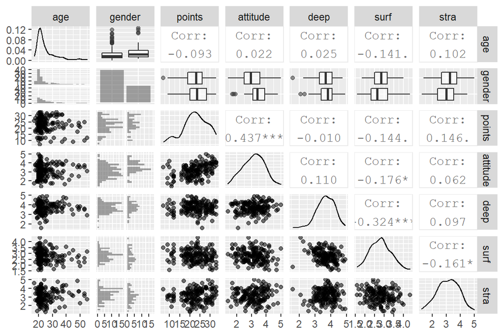

Other than age, which skews to the younger side, the variables look more or less normally distributes (except gender, of course, which is a categorical variable). Points seem to also have a small peak at the lower side (i.e. a small group of students got a very low amount of points and the rest seem normally distributed around the middle).

The highest correlation (0.43) is between attitude and points. Surface and deep have a moderate negative correlation (-0.32) a well. Maybe a slight correlation between surf and stra and surf and attitude as well.

We also plot data from male and female students separately.

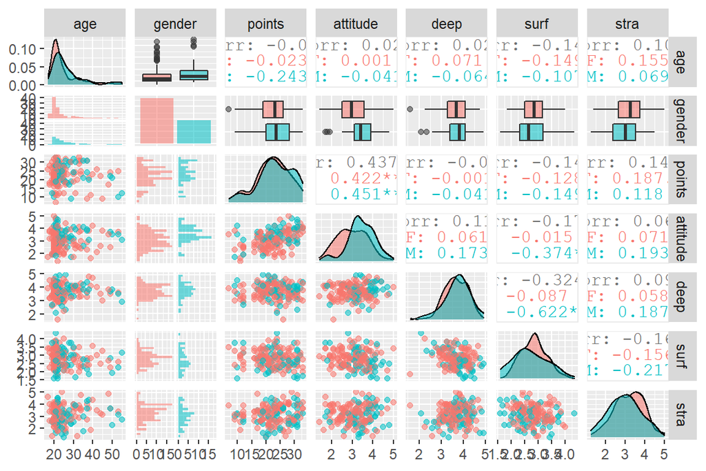

Doesn’t seem to be any major differences except maybe in attitude.

### 2.3 Building our regression model

Now, let’s create our regression model. Points will be dependent variable and we’ll choose attitude (attitude toward statistics), stra (strategic approach score) and surf (surface approach score) as the independent variables. The exercise didn’t seem to specify which one’s we should use so let’s just go with these.

```
##
## Call:
## lm(formula = points ~ attitude + stra + surf, data = learning2014)
##
## Residuals:
##      Min       1Q   Median       3Q      Max
## -17.1550  -3.4346   0.5156   3.6401  10.8952
##
## Coefficients:
##             Estimate Std. Error t value Pr(>|t|)
## (Intercept)  11.0171     3.6837   2.991  0.00322 **
## attitude      3.3952     0.5741   5.913 1.93e-08 ***
## stra          0.8531     0.5416   1.575  0.11716
## surf         -0.5861     0.8014  -0.731  0.46563
## ---
## Signif. codes:  0 '***' 0.001 '**' 0.01 '*' 0.05 '.' 0.1 ' ' 1
##
## Residual standard error: 5.296 on 162 degrees of freedom
## Multiple R-squared:  0.2074, Adjusted R-squared:  0.1927
## F-statistic: 14.13 on 3 and 162 DF,  p-value: 3.156e-08
```

We can see that attitude is the only significant variable in the model (i.e p < 0.05). The coefficient for attitude is 3.4 (i.e. when an increase of one in attitude score predicts an increase of 3.4 in exam points). Let’s get rid of the non-significant variables and fit a new model.